# Churn Analysis for ABC Wireless

Group 6

11/27/2019

Libraries required for Modelling.

```r
library(C50)
library(pROC)
library(caret)
```

```r
library(corrplot)
```

Loading the churn data from c50 library.

```r
##Selecting data
data(churn)

## Creating subset of actual data for Model 1
Train <- churnTrain

## Validation Data for Model 1
Valid <- churnTest

# Swaping levels of Churn attribute based on information provided so that we find the probability of Churn (Yes) while modeling.

Train$churn<- factor(Train$churn,levels(Train$churn)[c(2,1)])
Valid$churn<- factor(Valid$churn,levels(Valid$churn)[c(2,1)])
```

Model 1 : Assuming all the available attributes are significant for the Churn prediction.

```r
Train_1 <- Train
Valid_1 <- Valid

## Building a Logistic regression model using train data.

Model_1 <- glm(churn~.,data = Train_1,family = binomial(link='logit'))

## Predict values using based on training given to model
Model_Pre <- predict(Model_1,newdata = Valid_1,type = 'response')

## Detail of model built
summary(Model_1)
```

```
##
## Call:
## glm(formula = churn ~ ., family = binomial(link = "logit"), data = Train_1)
##
## Deviance Residuals:
##     Min       1Q   Median       3Q      Max
## -1.9487  -0.4995  -0.3123  -0.1661   3.0431
##
## Coefficients:
##                                 Estimate Std. Error z value Pr(>|z|)
## (Intercept)                   -9.686e+00  9.798e-01  -9.885  < 2e-16 ***
## stateAL                        3.385e-01  7.629e-01   0.444 0.657272
## stateAR                        9.106e-01  7.519e-01   1.211 0.225884
## stateAZ                        8.973e-02  8.452e-01   0.106 0.915453
## stateCA                        1.816e+00  7.822e-01   2.322 0.020238 *
## stateCO                        6.445e-01  7.631e-01   0.845 0.398339
## stateCT                        1.021e+00  7.252e-01   1.408 0.159167
## stateDC                        6.880e-01  8.081e-01   0.851 0.394577
## stateDE                        7.460e-01  7.490e-01   0.996 0.319234
## stateFL                        5.916e-01  7.610e-01   0.777 0.436956
## stateGA                        6.601e-01  7.778e-01   0.849 0.396075
## stateHI                       -2.300e-01  8.963e-01  -0.257 0.797469
## stateIA                        2.083e-01  9.024e-01   0.231 0.817410
## stateID                        8.705e-01  7.474e-01   1.165 0.244100
## stateIL                       -2.382e-01  8.340e-01  -0.286 0.775165
## stateIN                        4.410e-01  7.526e-01   0.586 0.557924
## stateKS                        1.062e+00  7.296e-01   1.455 0.145659
## stateKY                        7.889e-01  7.658e-01   1.030 0.302931
## stateLA                        5.546e-01  8.352e-01   0.664 0.506716
## stateMA                        1.161e+00  7.430e-01   1.562 0.118261
## stateMD                        1.144e+00  7.168e-01   1.596 0.110430
## stateME                        1.327e+00  7.281e-01   1.823 0.068321 .
## stateMI                        1.390e+00  7.137e-01   1.948 0.051400 .
## stateMN                        1.160e+00  7.149e-01   1.622 0.104709
## stateMO                        5.979e-01  7.741e-01   0.772 0.439914
## stateMS                        1.355e+00  7.278e-01   1.862 0.062601 .
## stateMT                        1.865e+00  7.166e-01   2.603 0.009245 **
## stateNC                        5.765e-01  7.545e-01   0.764 0.444822
## stateND                        1.274e-01  7.969e-01   0.160 0.872995
## stateNE                        2.952e-01  8.055e-01   0.367 0.713984
```

[output cut: 35 more lines]

```
## total_night_charge             5.039e+00  2.010e+01   0.251 0.802042
## total_intl_minutes            -4.149e+00  5.494e+00  -0.755 0.450194
## total_intl_calls              -9.055e-02  2.575e-02  -3.516 0.000438 ***
## total_intl_charge              1.567e+01  2.035e+01   0.770 0.441115
## number_customer_service_calls  5.366e-01  4.100e-02  13.089  < 2e-16 ***
## ---
## Signif. codes:  0 '***' 0.001 '**' 0.01 '*' 0.05 '.' 0.1 ' ' 1
##
## (Dispersion parameter for binomial family taken to be 1)
##
##     Null deviance: 2758.3  on 3332  degrees of freedom
## Residual deviance: 2070.8  on 3263  degrees of freedom
## AIC: 2210.8
##
## Number of Fisher Scoring iterations: 6
```

There are certain variables having very less z value and thus can be excluded while model building.

```r
## Finding accuracy for the model
## Formulated function to run a sequence to find probability and its accuracy

seq1 <- data.frame(cutoff = seq(.5,0.9,0.1),accuracy=rep(0,5))

for(i in 1:5)
{
  Model_Pre_lables <- as.factor(ifelse(Model_Pre>seq1$cutoff[i],"yes","no") )
  seq1[i,2]<-confusionMatrix(Model_Pre_lables,Valid_1$churn)$overall[1]
}

## shows threshold of probality with its accuracy
seq1
```

```
##   cutoff  accuracy
## 1    0.5 0.8692262
## 2    0.6 0.8734253
## 3    0.7 0.8722256
## 4    0.8 0.8722256
## 5    0.9 0.8698260
```

```r
## Show predition of each entry in validation data
Model_Pre_lables <- as.factor(ifelse(Model_Pre>seq1$cutoff[which.max(seq1$accuracy)] ,"yes","no"))

## Gives overall view of models performance
confusionMatrix(Model_Pre_lables,Valid_1$churn)
```

```
## Confusion Matrix and Statistics
##
##           Reference
## Prediction   no  yes
##        no  1418  186
##        yes   25   38
##
##                Accuracy : 0.8734
##                  95% CI : (0.8565, 0.889)
##     No Information Rate : 0.8656
##     P-Value [Acc > NIR] : 0.1851
##
##                   Kappa : 0.2187
##
##  Mcnemar's Test P-Value : <2e-16
##
##             Sensitivity : 0.9827
##             Specificity : 0.1696
##          Pos Pred Value : 0.8840
##          Neg Pred Value : 0.6032
##              Prevalence : 0.8656
##          Detection Rate : 0.8506
##    Detection Prevalence : 0.9622
##       Balanced Accuracy : 0.5762
##
##        'Positive' Class : no
##
```

```r
roc(Valid_1$churn,Model_Pre)
```

```
##
## Call:
## roc.default(response = Valid_1$churn, predictor = Model_Pre)
##
## Data: Model_Pre in 1443 controls (Valid_1$churn no) < 224 cases (Valid_1$churn yes).
## Area under the curve: 0.8331
```

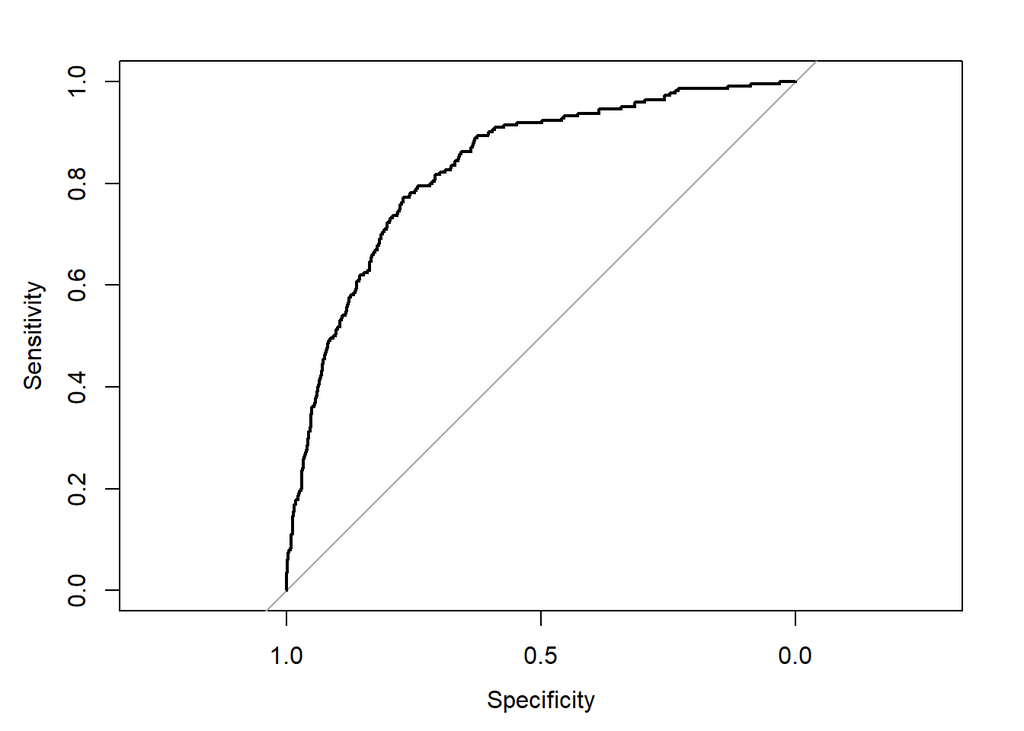

```r
plot(roc(Valid_1$churn,Model_Pre))
```

Based on the information of the gathered from above model we see accuracy as 87.34%, with high sensitivity and low level of specificity. ROC is 83.31%.

**Comments** Since we have build model based on all attributes of data, we further analyze to see if there are possibilities to reduce certain variable and check the predictive information of the model.

Model 2: Building a simplified model with reduced number of variables.

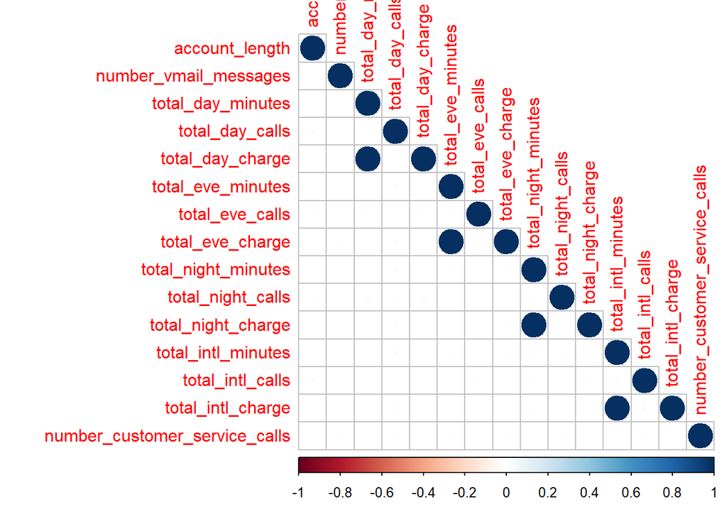

```r
## Creating subset of actual data

Train_2<- Train[,-c(1,3)]
Valid_2<- Valid[,-c(1,3)]

## To find if their is any corelation between vaiables by excluding catagorical variable.

corrplot(cor(Train_2[,-c(2,3,18)]),type = "lower")
```

** Comments ** : We can infer that total minutes and total charge for day,evening,night and international are highly correlated. This implies that higher the minute, higher is the charges- thus we can exclude either one of them.

```r
#Excluding all minute across all category

Train_2<- Train_2[,-c(5,8,11,14)]
Valid_2<- Valid_2[,-c(5,8,11,14)]

## Building logistic regression model using altered train data.

Model_2 <- glm(churn~.,data = Train_2,family = binomial(link='logit'))

## Predict values using based on training given to model

Model_Pre_2 <- predict(Model_2,newdata = Valid_2,type = 'response')
summary(Model_2)
```

```
##
## Call:
## glm(formula = churn ~ ., family = binomial(link = "logit"), data = Train_2)
##
## Deviance Residuals:
##     Min       1Q   Median       3Q      Max
## -2.1341  -0.5120  -0.3398  -0.1954   3.2626
##
## Coefficients:
##                                 Estimate Std. Error z value Pr(>|z|)
## (Intercept)                   -8.6558865  0.7242648 -11.951  < 2e-16 ***
## account_length                 0.0008334  0.0013913   0.599 0.549142
## international_planyes          2.0373143  0.1453553  14.016  < 2e-16 ***
## voice_mail_planyes            -2.0075786  0.5732018  -3.502 0.000461 ***
## number_vmail_messages          0.0353455  0.0179863   1.965 0.049399 *
## total_day_calls                0.0032139  0.0027575   1.166 0.243805
## total_day_charge               0.0763955  0.0063738  11.986  < 2e-16 ***
## total_eve_calls                0.0010730  0.0027805   0.386 0.699580
## total_eve_charge               0.0852189  0.0134450   6.338 2.32e-10 ***
## total_night_calls              0.0006893  0.0028398   0.243 0.808206
## total_night_charge             0.0822072  0.0246791   3.331 0.000865 ***
## total_intl_calls              -0.0920574  0.0250065  -3.681 0.000232 ***
## total_intl_charge              0.3253095  0.0755019   4.309 1.64e-05 ***
## number_customer_service_calls  0.5137234  0.0392394  13.092  < 2e-16 ***
## ---
## Signif. codes:  0 '***' 0.001 '**' 0.01 '*' 0.05 '.' 0.1 ' ' 1
##
## (Dispersion parameter for binomial family taken to be 1)
##
##     Null deviance: 2758.3  on 3332  degrees of freedom
## Residual deviance: 2159.7  on 3319  degrees of freedom
## AIC: 2187.7
##
## Number of Fisher Scoring iterations: 6
```

```r
## Finding accuracy for the model
seq2 <- data.frame(cutoff = seq(.5,0.9,0.1),accuracy=rep(0,5))

for(i in 1:5)
{
  Model_Pre_lables_2 <- as.factor(ifelse(Model_Pre_2>seq2$cutoff[i],"yes","no") )
  seq2[i,2]<-confusionMatrix(Model_Pre_lables_2,Valid_2$churn)$overall[1]

}

seq2
```

```
##   cutoff  accuracy
## 1    0.5 0.8716257
## 2    0.6 0.8764247
## 3    0.7 0.8740252
## 4    0.8 0.8728254
## 5    0.9 0.8698260
```

```r
Model_Pre_lables_2 <- as.factor(ifelse(Model_Pre_2>seq2$cutoff[which.max(seq2$accuracy)] ,"yes","no") )

## Overall view of model performance

confusionMatrix(Model_Pre_lables_2,Valid_2$churn)
```

```
## Confusion Matrix and Statistics
##
##           Reference
## Prediction   no  yes
##        no  1426  189
##        yes   17   35
##
##                Accuracy : 0.8764
##                  95% CI : (0.8597, 0.8918)
##     No Information Rate : 0.8656
##     P-Value [Acc > NIR] : 0.1034
##
##                   Kappa : 0.2138
##
##  Mcnemar's Test P-Value : <2e-16
##
##             Sensitivity : 0.9882
##             Specificity : 0.1562
##          Pos Pred Value : 0.8830
##          Neg Pred Value : 0.6731
##              Prevalence : 0.8656
##          Detection Rate : 0.8554
##    Detection Prevalence : 0.9688
##       Balanced Accuracy : 0.5722
##
##        'Positive' Class : no
##
```

```r
roc(Valid_2$churn,Model_Pre_2)
```

```
##
## Call:
## roc.default(response = Valid_2$churn, predictor = Model_Pre_2)
##
## Data: Model_Pre_2 in 1443 controls (Valid_2$churn no) < 224 cases (Valid_2$churn yes).
## Area under the curve: 0.8408
```

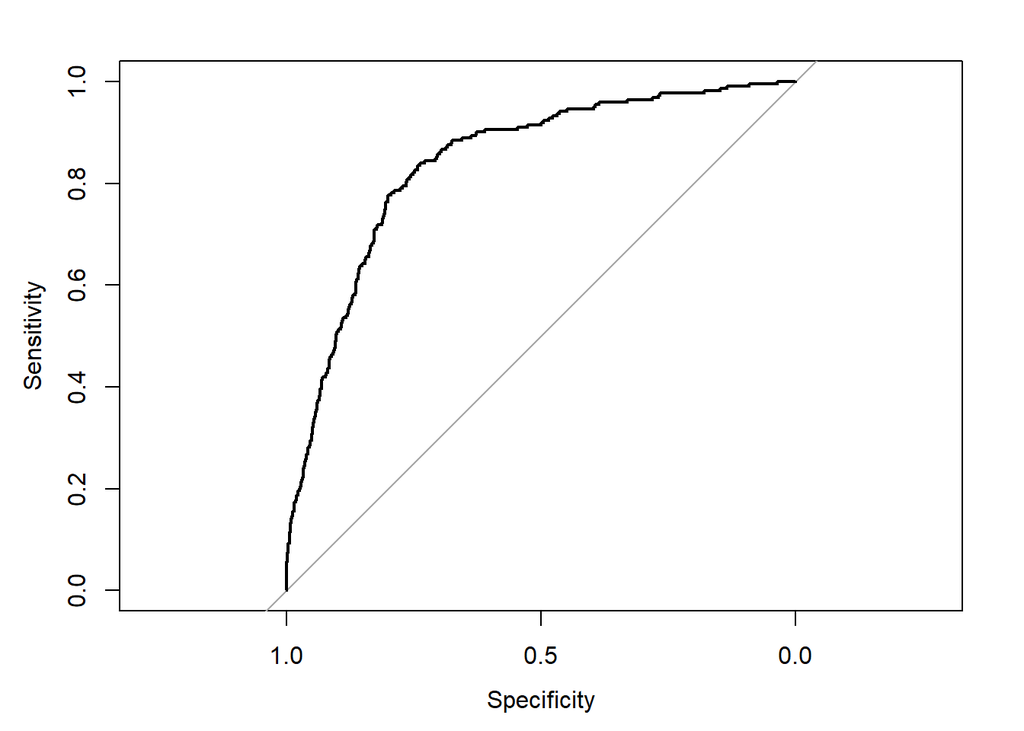

```r
plot(roc(Valid_2$churn,Model_Pre_2))
```

By building a model with lesser number of variables we can see that the predictive capability of the model have increased.

This can be proven by the AIC values of the model. AIC: Model 1 = 2210 Model 2 = 2187

##Comments** : We can infer by reducing variables we not only increase the AUC of the model we are reducing complexity of the model

Model 3 : Excluding the attributes with negligible significance.

Building model to reduce variable which are least significant and see we have any change in AUC of the model

```r
Train_3<- Train[,-c(1:3,7,8,10,11,13,14,16)]
Valid_3<- Valid[,-c(1:3,7,8,10,11,13,14,16)]

levels(Train_3$churn)
```

```
## [1] "no"  "yes"
```

```r
Model_3 <- glm(churn~.,data = Train_3,family = binomial(link='logit'))
Model_Pre_3 <- predict(Model_3,newdata = Valid_3,type = 'response')

summary(Model_3)
```

```
##
## Call:
## glm(formula = churn ~ ., family = binomial(link = "logit"), data = Train_3)
##
## Deviance Residuals:
##     Min       1Q   Median       3Q      Max
## -2.1203  -0.5133  -0.3375  -0.1969   3.2420
##
## Coefficients:
##                                Estimate Std. Error z value Pr(>|z|)
## (Intercept)                   -8.067137   0.515875 -15.638  < 2e-16 ***
## international_planyes          2.040325   0.145243  14.048  < 2e-16 ***
## voice_mail_planyes            -2.003143   0.572347  -3.500 0.000465 ***
## number_vmail_messages          0.035258   0.017964   1.963 0.049674 *
## total_day_charge               0.076590   0.006371  12.022  < 2e-16 ***
## total_eve_charge               0.084495   0.013433   6.290 3.17e-10 ***
## total_night_charge             0.082549   0.024653   3.348 0.000813 ***
## total_intl_calls              -0.092175   0.024988  -3.689 0.000225 ***
## total_intl_charge              0.326138   0.075453   4.322 1.54e-05 ***
## number_customer_service_calls  0.512257   0.039141  13.087  < 2e-16 ***
## ---
## Signif. codes:  0 '***' 0.001 '**' 0.01 '*' 0.05 '.' 0.1 ' ' 1
##
## (Dispersion parameter for binomial family taken to be 1)
##
##     Null deviance: 2758.3  on 3332  degrees of freedom
## Residual deviance: 2161.6  on 3323  degrees of freedom
## AIC: 2181.6
##
## Number of Fisher Scoring iterations: 6
```

```r
## Finding accuracy for the model
seq3 <- data.frame(cutoff = seq(.5,0.9,0.1),accuracy=rep(0,5))

for(i in 1:5)
{
  Model_Pre_lables_3 <- as.factor(ifelse(Model_Pre_3>seq3$cutoff[i],"yes","no"))
  seq3[i,2]<-confusionMatrix(Model_Pre_lables_3,Valid_3$churn)$overall[1]
}

seq3
```

```
##   cutoff  accuracy
## 1    0.5 0.8698260
## 2    0.6 0.8764247
## 3    0.7 0.8746251
## 4    0.8 0.8734253
## 5    0.9 0.8698260
```

```r
## Show predition of each entry in validation data
Model_Pre_lables_3 <- as.factor(ifelse(Model_Pre_3>seq3$cutoff[which.max(seq3$accuracy)] ,"yes","no"))

confusionMatrix(Model_Pre_lables_3,Valid_3$churn)
```

```
## Confusion Matrix and Statistics
##
##           Reference
## Prediction   no  yes
##        no  1428  191
##        yes   15   33
##
##                Accuracy : 0.8764
##                  95% CI : (0.8597, 0.8918)
##     No Information Rate : 0.8656
##     P-Value [Acc > NIR] : 0.1034
##
##                   Kappa : 0.2049
##
##  Mcnemar's Test P-Value : <2e-16
##
##             Sensitivity : 0.9896
##             Specificity : 0.1473
##          Pos Pred Value : 0.8820
##          Neg Pred Value : 0.6875
##              Prevalence : 0.8656
##          Detection Rate : 0.8566
##    Detection Prevalence : 0.9712
##       Balanced Accuracy : 0.5685
##
##        'Positive' Class : no
##
```

```r
roc(Valid_3$churn,Model_Pre_3)
```

```
##
## Call:
## roc.default(response = Valid_3$churn, predictor = Model_Pre_3)
##
## Data: Model_Pre_3 in 1443 controls (Valid_3$churn no) < 224 cases (Valid_3$churn yes).
## Area under the curve: 0.8413
```

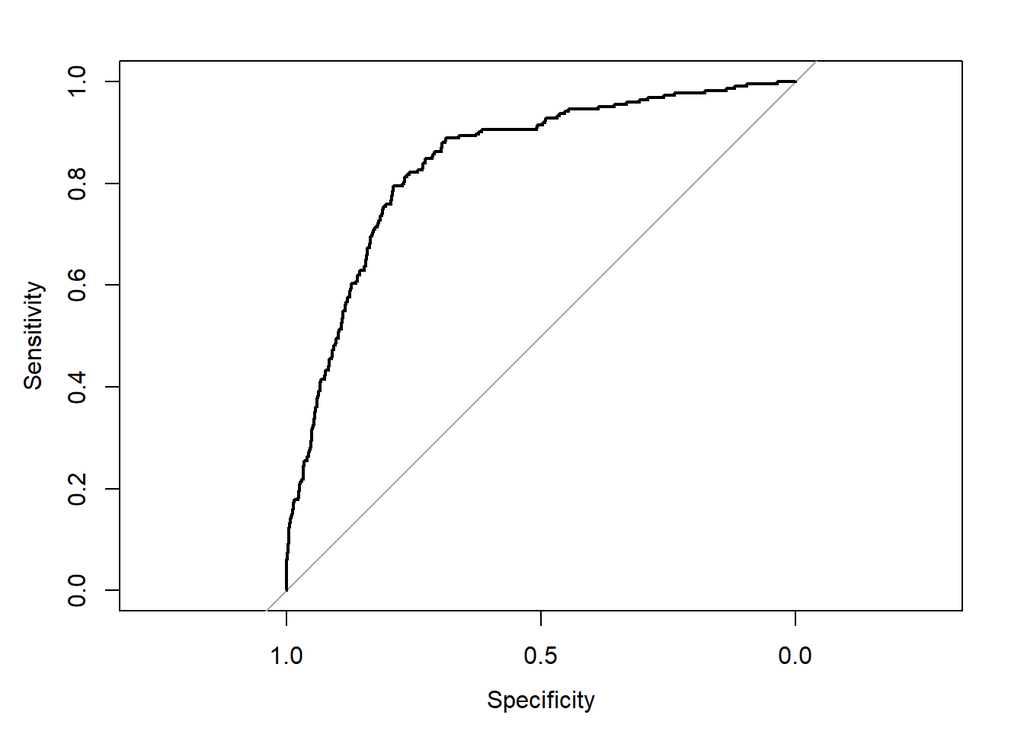

```r
plot(roc(Valid_3$churn,Model_Pre_3))
```

##*Comment* : AUC of the model is same with less no. of variable with threshold as :0.6

By looking at the significance of the varibale after the model is built all the considered attributes are significant hence we cannot reduce any other variable.

The AIC value do not show much deviation between the model 2 and 3 thus we have considered this Model 3 as our final model with 9 variables to predict the churn.

The ROC we computed is 84.13% with good confusion matrix calculations.

## Predicting for Customers_To_Predict

```r
#write.csv(Customers_To_Predict, "Customers_To_Predict.csv")

Customers_To_Predict_data <- read.csv("Customers_To_Predict.csv")

Customers_To_Predict <- Customers_To_Predict_data[,-c(1:3,7,8,10,11,13,14,16)]

Model_Pre_Test <- predict(Model_3,newdata = Customers_To_Predict,type = 'response')

Probablity_Churn <- Model_Pre_Test

Model_Pre_lables_Test <- as.data.frame(as.factor(ifelse(Model_Pre_Test>.6,"yes","no")))

Probablity_Churn <- cbind(Probablity_Churn, Model_Pre_lables_Test)
colnames(Probablity_Churn) <- c("Probability", "Churn")

Probablity_Churn <- cbind(Customers_To_Predict_data, Probablity_Churn)

#write.csv(Probablity_Churn,"Prediction.csv")

prop.table(table(Model_Pre_lables_Test))*100
```

```
## Model_Pre_lables_Test
##   no  yes
## 96.7  3.3
```

Thus we can see the churn rate for Test data set is approximately 3%.